# Thinkful Final Capstone - Siting Wind Farms - Supervised Learning models slides

[In the first notebook for this capstone](https://github.com/iamjeremybe/thinkful_data_science/blob/master/Final%20Capstone/Thinkful%20Final%20Capstone%20-%20Siting%20Wind%20Farms.ipynb), I introduced the datasets, generated a target feature using an unsupervised learning model, and detailed the use of some external scripts that generated additional features that can be used to train a supervised learning model.

In this notebook, we can run a supervised learning model, and analyze the candidate sites for new wind farms that the model suggests.

## Data: wrangled. Now, build something

Originally had two supervised learning models in mind:

1. Identify candidate sites for turbines
2. Given attributes of candidate sites, determine the best type of turbine (turbine_class) to put there.
- Built the first model
- turbine_class turned out to be more about project age and size than other turbine attributes like height, rotor diameter, etc.

The target variable for the supervised learning model is going to be a simple binary value, calculated based on two attributes:

- Whether or not turbines already exist in a location;
- Whether the wind_class variable from NREL's dataset with exclusions is high enough.

```python
nrel_state['target'] = np.where( (nrel_state['turbine_count'] > 0)\
                               | (nrel_state['wind_class_excl'] >= 3),
                                1, 0)
```

## Choosing a model

I focused primarily on classification models--the target variable is binary (good site, or bad site).

The input variables for our supervised learning model don't seem to lend themselves well to a pure regression model--there are a number of categorical variables, and the continuous variables are not normally distributed.

I evaluated the performance of three models:

- Support Vector Machine (Classifier)
- Stochastic Gradient Descent Classifier
- Random Forest Classifier

### SVM (SVC specifically)

There are relatively few input variables, and we are performing binary classification, at which SVM is supposed to excel.

I tried the default 'rbf' kernel as well as the 'poly'(nomial) kernel.

I tried normalizing the input data, but it produced the same score as the raw input.

With no tuning, this SVC model scores well by declaring *everywhere* to be a good candidate site. I tried adding a class_weight to make the prediction of non-candidate sites more important--it helped a bit, but the weights mostly caused the model to generate a bunch of false positives and false negatives.

### SGD Classifier / single fit

I had a thought to try incremental learning--to generate a full set of data for every state, and train a model using all of those datasets. Unfortunately, generating 48 states' worth of data turned out to be a major challenge in terms of processing time, power, and disk space.

Had I the resources to proceed with that plan, I would replace .fit() below with .partial_fit(), and feed in states' training datasets one by one.

The SGD classifier performs well enough training against a single dataset.

The SGD model is misclassifying both non-candidate sites, and candidate sites, but is particularly bad at identifying non-candidate sites.

I tried adding class weights, but in the end they do not seem to help this model do a better job at identifying non-candidate sites.

### Random Forest

The augmented NREL dataset doesn't have a lot of features, so I thought perhaps a random forest would be easy to train. As it turns out--yes!

Depending on the state, the test set will score at or above 90% with no additional tuning. (Kansas' test dataset returns a score of 94%!)

The random forest's cross-validation scores suggest this model is overfitting to a degree that the SGD classifier does not, even after some attempts to tune it.

On the other hand, the random forest's confusion matrix, and the stats derived from it, look better than the SDG classifier's results--the random forest model is much better at correctly identifying non-candidate sites. I'd like to proceed using it.

### Comparing models' performance

Since these are classifer models, we can use confusion matrices, and statistics derived from them, to help us understand which model is performing the best.

We can also examine cross-validation scores to determine whether a model is overfitting.

### Accuracy, Precision and Recall

Each model's mean accuracy is represented by the model's attribute, score. This tells us how well each model did at correctly classifying all observations--it is the fraction of correct predictions for the entire dataset.

Precision tells us the fraction of positive predictions that are correct (true positives over all positives, true or false).

Recall is a fraction describing how many of the predicted positives are correct, out of all of the true positives (so, positive observations the model correctly classified as positive, and mistakenly identified as negative).

Precision and recall have been broken out by class.

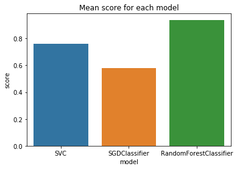

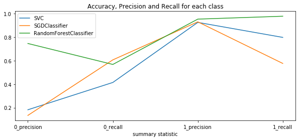

```python
plot_model_stats(model_stats)
```

### Random Forest feature importance

```
Feature ranking:
1. feature 3: SHAPE__Len (0.436022)
2. feature 5: VOLTAGE (0.225333)
3. feature 0: volt_class_encoded (0.164414)
4. feature 4: dist_to_nearest_line (0.158407)
5. feature 2: line_count (0.008135)
6. feature 1: wind_class (0.007689)
```

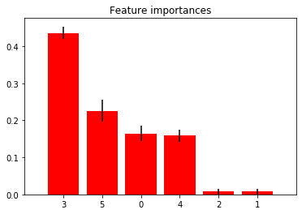

```python
show_feat_importance(rfc,X_train1.drop('geometry',axis='columns'))
```

## Putting it together - supervised learning model output + unsupervised learning model output

**In the plot below of our test dataset:**

- Candidate sites chosen by the supervised learning model are shaded blue; transmission lines are drawn in grey.
- Turbines are colored according to the same color scheme assigned in the analysis of the unsupervised learning model.

**Together, these datasets give us a high-level picture of what currently exists, and where we can look next.**

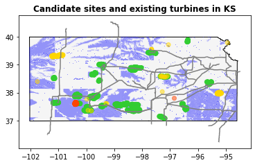

```
Non-candidate sites: 795; candidate sites: 7356
```

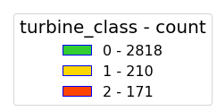

```python
plot_candidate_sites(X_test_out1.loc[X_test_out1['build_here'] == 1],turbines_state,power_state,target_frequency)
```

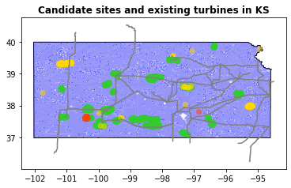

```
Non-candidate sites: 2086; candidate sites: 22614
```

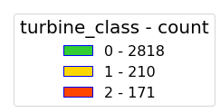

```python
# When the model is applied to the state's entire dataset:
plot_candidate_sites(nrel_state.loc[nrel_state['build_here'] == 1],
                     turbines_state, power_state,
                     pd.Series(np.unique(build_or_not,return_counts=True)[1]))
```

Most of the state of Kansas has a high enough NREL wind class to qualify as a candidate site.

Adding additional factors to the criteria for a good candidate site could further whittle down these results:

- If a household survey of an area showed that the majority of residents were openly hostile to being neighbors to a wind farm;
- If wildlife observations showed that the area was frequented by bats or migratory birds known to not interact well with turbines.

## What differentiates good candidate sites from other sites?

We can look at the distributions for non-candidate sites vs. candidate sites, and check out the differences between their summary statistics (mean, median, standard deviation).

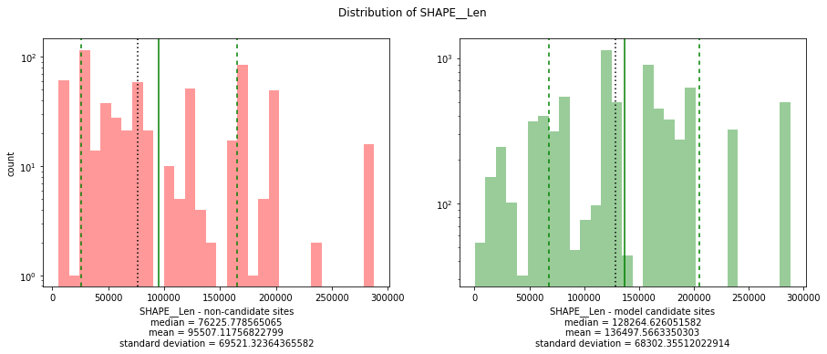

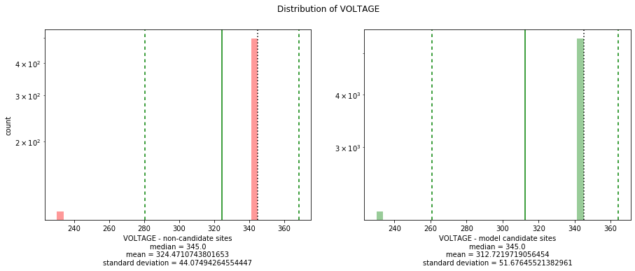

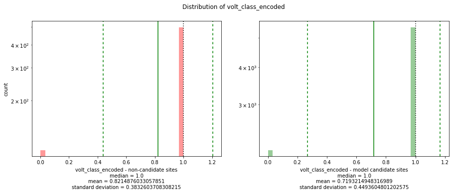

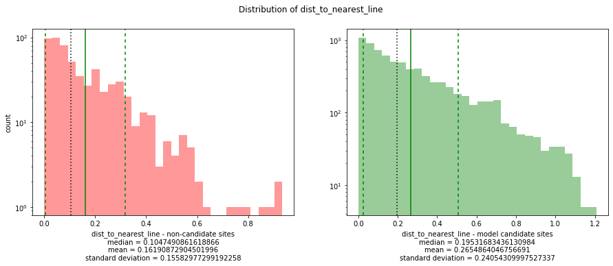

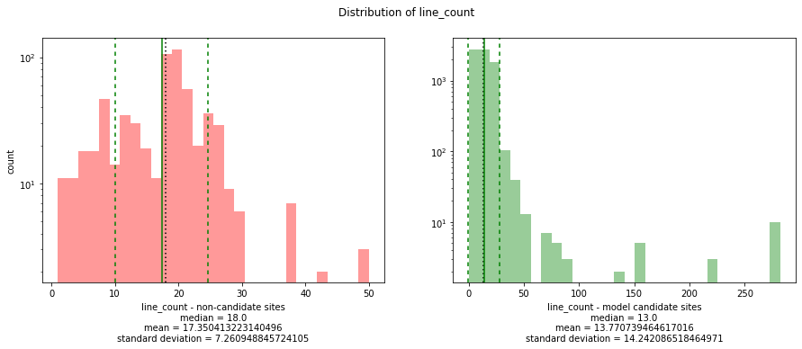

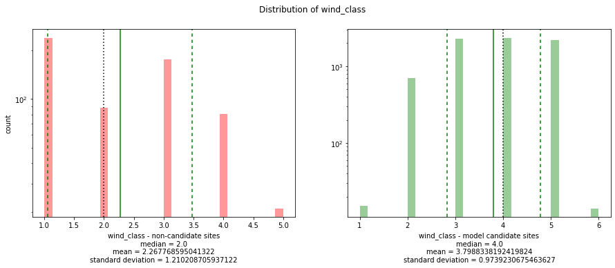

```python
for feature in X_test_out1.drop('geometry',axis='columns').columns:
    if feature == 'build_here':
        continue
    score_distribution(X_test_out1,feature)
```

### Summary of non-candidate vs. candidate sites

- NREL wind_class was one of the least important features to the random forest model! Candidate sites do have a higher mean wind_class than non-candidate sites.
- Transmission line attributes were the highest-ranking features. with the length of the nearest line at the top of the list.
- Longer transmission lines that are farther away seem to be good indicators of the best candidate sites.
- Voltage and volt class were important to the model, even though the overwhelming majority of transmission lines are 345 volts, and belong to the same class.
- I intended to add a weight to line count, but am glad I didn't invest the time and energy--line count doesn't seem to mean much to the model anyway.

## Conclusions

Even with data for only a few of the AWEA's most important factors available, this model does a reasonably good job of suggesting candidate sites for turbines.

Considering that most of the features fed to the random forest model were related to the transmission lines close to candidate sites--and considering transmission lines did not figure into AWEA's four main considerations of siting a wind project--I'm pleasantly surprised to see the model performing as well as it does!

I was disappointed to not be able to make better use of the turbine_class feature produced by the unsupervised learning model, but its outputs still led to some useful insights about how the technology has changed over time.

## Future work

- In a production environment, this data would need to be updated periodically. The scripts I wrote are a good start, but they represent a compromise of time vs. available resources for processing. Moving this processing to a cloud environment would open up the possibility of spinning up additional virtual machines to handle the capacity.
- Find more topographic and wind data. NREL's datasets are a decent start, but I feel that some information may be lost in their reduction of so many factors to a single class.
- Incorporate other data, create additional features--such as a feature that negatively weighs a site if it is determined that "shadow flicker" from moving turbines would affect residents in nearby homes.
- I would suggest adding a weight to the density of power lines, to negatively weigh density that represents an urban area, or an area otherwise unsuited to wind turbines...but the random forest model didn't consider line_count very important in its calculations anyway.
- Gather data for other parts of the world, especially offshore locations.
- Make the output of the supervised learning model more granular? 1 degree of latitude/longitude is a large area to make a single prediction.
- Create an interactive dashboard. [Folium](https://python-visualization.github.io/folium/quickstart.html) looked promising!

# Thank you!

[figure not shown]